# Problem set 4 _Alejandro Cotes

_Alejandro Cotes

2024-06-05

```r
# URL de la página original
url <- "https://eduard-martinez.github.io/pset-4.html"

# Leer el contenido de la página original
webpage <- read_html(url)

# Extraer todas las URLs contenidas en los enlaces de la página original
urls <- webpage %>%
  html_nodes("a") %>%
  html_attr("href")

# Crear un objeto que almacene el vector de URLs
url_full <- urls

# Mostrar las URLs completas
head(url_full)
```

```
## [1] "index.html"
## [2] "index.html"
## [3] "research.html"
## [4] "https://eduard-martinez.github.io/cv/CV-Eduard_F_Martinez_G.pdf"
## [5] "teaching.html"
## [6] "blog.html"
```

```r
# Filtrar las URLs que contienen la palabra "propiedad"
url_subset <- url_full[grepl("propiedad", url_full)]

# Mostrar las URLs filtradas
head(url_subset)
```

```
## [1] "https://eduard-martinez.github.io/pset-4/propiedad_1.html"
## [2] "https://eduard-martinez.github.io/pset-4/propiedad_2.html"
## [3] "https://eduard-martinez.github.io/pset-4/propiedad_3.html"
## [4] "https://eduard-martinez.github.io/pset-4/propiedad_4.html"
## [5] "https://eduard-martinez.github.io/pset-4/propiedad_5.html"
## [6] "https://eduard-martinez.github.io/pset-4/propiedad_6.html"
```

```r
# Inicializar una lista vacía para almacenar las tablas
lista_tablas <- list()

# Iterar sobre cada URL en url_subset
for (url in url_subset) {
  # Leer el contenido de la página
  webpage <- read_html(url)

  # Extraer la tabla (asumimos que la tabla está presente y es la primera en la página)
  tabla <- webpage %>%
    html_node("table") %>%
    html_table()

  # Añadir la tabla a la lista
  lista_tablas <- append(lista_tablas, list(tabla))
}

# Convertir la lista de tablas en un único data frame
db_house <- rbindlist(lista_tablas, fill = TRUE)

# Mostrar el contenido de db_house
head(db_house)
```

```
##        V1     V1 rooms bedrooms bathrooms surface_total surface_covered
##     <int>  <int> <int>    <int>     <int>         <int>           <int>
## 1: 162357 162357    NA        3         3           115              NA
## 2: 209310 209310    NA       NA         2            NA              NA
## 3: 139333 139333    NA       NA        NA            NA              NA
## 4: 161433 161433    NA       NA         6           822              NA
## 5: 140273 140273     6        6         3           253             370
## 6: 203282 203282    NA        3         2            NA              NA
##       price property_type      lat       lon                   geometry
##       <num>        <char>    <num>     <num>                     <char>
## 1: 6.40e+08   Apartamento 4.717989 -74.07909 POINT (-74.07909 4.717989)
## 2: 1.75e+08          Otro 4.760000 -74.03400       POINT (-74.034 4.76)
## 3: 3.99e+08   Apartamento 4.588000 -74.11000       POINT (-74.11 4.588)
## 4: 3.60e+09      Depósito 4.666264 -74.08338 POINT (-74.08338 4.666264)
## 5: 5.00e+08          Casa 4.733000 -74.08900      POINT (-74.089 4.733)
## 6: 2.60e+08   Apartamento 4.768361 -74.04681 POINT (-74.04681 4.768361)
```

```r
# Convertir el data frame en un objeto SimpleFeature
# Asumimos que db_house tiene columnas 'lon' y 'lat'
sf_house <- st_as_sf(db_house, coords = c("lon", "lat"), crs = 4326)

# Mostrar el contenido de sf_house
print(sf_house)
```

```
## Simple feature collection with 220 features and 9 fields
## Geometry type: POINT
## Dimension:     XY
## Bounding box:  xmin: -74.21875 ymin: 4.467 xmax: -74.02463 ymax: 4.819964
## Geodetic CRS:  WGS 84
## First 10 features:
##        V1   V1.1 rooms bedrooms bathrooms surface_total surface_covered
## 1  162357 162357    NA        3         3           115              NA
## 2  209310 209310    NA       NA         2            NA              NA
## 3  139333 139333    NA       NA        NA            NA              NA
## 4  161433 161433    NA       NA         6           822              NA
## 5  140273 140273     6        6         3           253             370
## 6  203282 203282    NA        3         2            NA              NA
## 7  197741 197741     4        4         4           280             280
## 8  135130 135130    NA        3         4            NA              NA
## 9  185192 185192    NA       NA         4            NA              NA
## 10  54089  54089     3        3        NA            NA              NA
##       price property_type                   geometry
## 1  6.40e+08   Apartamento POINT (-74.07909 4.717989)
## 2  1.75e+08          Otro       POINT (-74.034 4.76)
## 3  3.99e+08   Apartamento       POINT (-74.11 4.588)
## 4  3.60e+09      Depósito POINT (-74.08338 4.666264)
## 5  5.00e+08          Casa      POINT (-74.089 4.733)
## 6  2.60e+08   Apartamento POINT (-74.04681 4.768361)
## 7  2.80e+09   Apartamento      POINT (-74.027 4.685)
## 8  8.75e+08   Apartamento POINT (-74.03502 4.697425)
## 9  2.30e+09   Apartamento POINT (-74.03451 4.716734)
## 10 4.35e+08   Apartamento POINT (-74.11119 4.658833)
```

```
## Zoom: 10
```

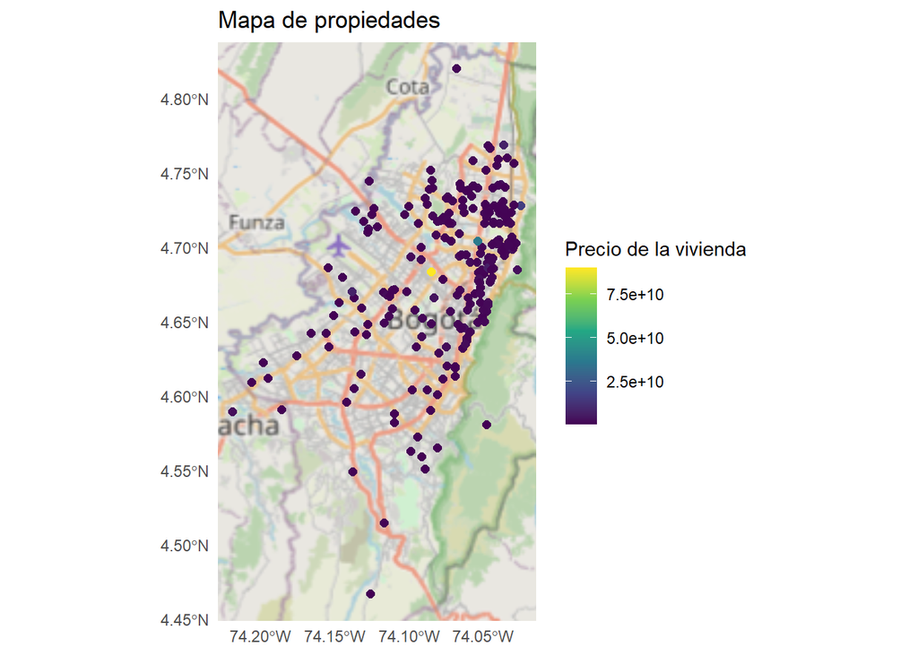

```r
# Crear el mapa usando ggplot2 y ggspatial
mapa <- ggplot(data = sf_house) +
  annotation_map_tile("osm") +  # Añadir el mapa base de OpenStreetMap
  geom_sf(aes(color = price), size = 2) +  # Asumimos que la columna de precios se llama 'Precio'
  scale_color_viridis_c(option = "D") +
  theme_minimal() +
  labs(title = "Mapa de propiedades",
       color = "Precio de la vivienda")

# Mostrar el mapa
print(mapa)
```

```r
# Exportar el mapa en formato PDF
ggsave("mapa_propiedades.pdf", plot = mapa)
```

```
## Zoom: 10
```

```r
# Crear variables dummy para rooms, bedrooms, bathrooms y property_type
sf_house$rooms <- factor(sf_house$rooms, levels = 1:12)
sf_house$bedrooms <- factor(sf_house$bedrooms, levels = 1:12)
sf_house$bathrooms <- factor(sf_house$bathrooms, levels = 1:10)
sf_house$property_type <- factor(sf_house$property_type, levels = c("Casa", "Apartamento", "Depósito", "Otro"))

# Ajustar el modelo de regresión lineal
model <- lm(price ~ rooms + bedrooms + bathrooms + surface_total + surface_covered + property_type, data = sf_house)

# Mostrar los resultados del modelo
summary(model)
```

```
##
## Call:
## lm(formula = price ~ rooms + bedrooms + bathrooms + surface_total +
##     surface_covered + property_type, data = sf_house)
##
## Residuals:
##        Min         1Q     Median         3Q        Max
## -438217410 -111038101          0   46729985  490259501
##
## Coefficients: (5 not defined because of singularities)
##                            Estimate Std. Error t value Pr(>|t|)
## (Intercept)              -5.213e+08  6.948e+08  -0.750   0.4775
## rooms2                    8.179e+07  4.102e+08   0.199   0.8476
## rooms3                   -2.822e+08  3.999e+08  -0.706   0.5033
## rooms4                    6.504e+07  5.937e+08   0.110   0.9158
## rooms6                   -2.088e+09  8.873e+08  -2.354   0.0508 .
## rooms12                  -6.699e+08  1.080e+09  -0.620   0.5547
## bedrooms2                        NA         NA      NA       NA
## bedrooms3                        NA         NA      NA       NA
## bedrooms4                        NA         NA      NA       NA
## bedrooms6                        NA         NA      NA       NA
## bedrooms12                       NA         NA      NA       NA
## bathrooms2                3.610e+07  2.819e+08   0.128   0.9017
## bathrooms3               -1.351e+08  3.787e+08  -0.357   0.7318
## bathrooms4               -3.703e+08  6.077e+08  -0.609   0.5615
## surface_total             7.065e+06  5.320e+06   1.328   0.2259
## surface_covered           3.939e+06  5.138e+06   0.767   0.4683
## property_typeApartamento  2.679e+08  5.252e+08   0.510   0.6256
## ---
## Signif. codes:  0 '***' 0.001 '**' 0.01 '*' 0.05 '.' 0.1 ' ' 1
##
## Residual standard error: 336700000 on 7 degrees of freedom
##   (201 observations deleted due to missingness)
## Multiple R-squared:  0.9212, Adjusted R-squared:  0.7974
## F-statistic: 7.442 on 11 and 7 DF,  p-value: 0.006848
```

### Conclusiones apartir de un modelo de regresión

El coeficiente de nuestra regresión suguiere que las viviendas de por si sola controlando por los demás variables constantes, nos dice que la vivienda asume poco valor. Sientas que el coeficienta de rooms que es el número de cuertos por casa suguiere que a más habitaciones más valor tiene la casa cuando tiene 2 o 4, sin embargo, cuando la casa tiene 3 , 6 y 12 habitaciones, el precio de la vivienda cae, posiblemente, porque, las viviendas en estratos de bajos recursos suelen tener más viviendas que las del promedio como medida de ahorro economico al concentrar varios habitantes dentro de la misma vivienda y ahorrar gastos en arriendo. Por otro lado, la variable bathroom, sugiere que las casas con menos baños valen más que las que más poseen baños, posiblemente bajo las misma hipotesis del número de habitaciones. Adicionalmente, parece que el tamaño de la casa con las varibles surface_total, surface_covered si influyen en aumentar el precio de la vivienda, al igual de la variable categorica property_typeApartamento que ordena desde casa, apartamento, deposito y otro, donde es logico suponer que un apartamento es más costoso que una casa y un deposito que un apartamento. A pesar de esto, no tenemos evidencia suficiente para tomar estas afirmaciones como efectos causales, dado que, la unica variable que es estadisticamente significativa al 10% es rooms6, la cual reduce el valor de la vivienda, es decir, posiblemente las viviendas más economicas y de bajos recursos tienen 6 habitaciones por vivienda. De hecho, resaltamos que seria importante más allá de las caracteristicas de la vivienda incluir controles adicionales como estrato socio economonico de la vivienda para poder explicar mejor la variable precio de la vivienda.